# Comparing Distributions

Kieran Healy

Duke University

2021-12-19

Abstract

Working document only

```r
## Keep track of labels for as_labeller() functions in faceting.
grp_names <- c(`a` = "Group A",
               `b` = "Group B",
               `c` = "Group C",
               `pop_a` = "Group A",
               `pop_b` = "Group B",
               `pop_c` = "Group C",
               `pop_total` = "Total",
               `A` = "Group A",
               `B` = "Group B",
               `C` = "Group C")
```

## Generate some data

Say we have some number of observed units, e.g., three thousand “counties” or whatever. Each county has some population. Across all counties the population is distributed log-normally around some mean county population. Populations are divided into groups within counties whose proportions vary across counties but always sum to one within each county.

```r
set.seed(1243098)

N <- 3e3
alphas <- c(1.5, 0.9, 2)

pop <- round(rlnorm(N, meanlog = 10.3, sdlog = 1.49), 0)

df <- as_tibble(gtools::rdirichlet(N, alphas),
                       .name_repair = "unique") %>%
  rename_with(~ c("a", "b", "c")) %>%
  rowid_to_column("unit") %>%
  add_column(pop_total = pop) %>%
  mutate(across(a:c,
                .fns = list(pop = ~ round(.x * pop_total, 0) + 1),
                .names = "{fn}_{col}"))

df
```

```
## # A tibble: 3,000 × 8
##     unit     a      b     c pop_total pop_a pop_b  pop_c
##    <int> <dbl>  <dbl> <dbl>     <dbl> <dbl> <dbl>  <dbl>
##  1     1 0.156 0.196  0.648      6467  1008  1269   4194
##  2     2 0.288 0.154  0.558    211075 60729 32579 117771
##  3     3 0.165 0.391  0.443    128243 21186 50184  56876
##  4     4 0.294 0.124  0.582     76843 22561  9555  44730
##  5     5 0.301 0.146  0.553     12178  3671  1780   6730
##  6     6 0.397 0.148  0.455      2707  1076   401   1232
##  7     7 0.364 0.258  0.378    143261 52112 36987  54166
##  8     8 0.859 0.0375 0.103     61109 52517  2290   6305
##  9     9 0.129 0.477  0.394     61718  7968 29433  24320
## 10    10 0.185 0.182  0.632      3217   597   588   2035
## # … with 2,990 more rows
```

We can look at the distribution of group populations across counties:

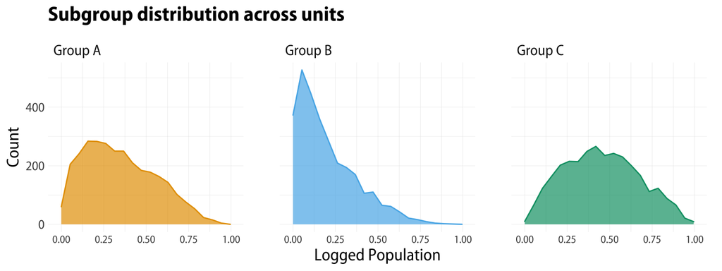

```r
df %>%
  pivot_longer(a:c) %>%
  ggplot() +
  geom_area(mapping = aes(x = value, y = ..count..,
                          color = name, fill = name),
            stat = "bin", bins = 20, size = 0.5) +
  scale_fill_manual(values = alpha(my_oka, 0.7)) +
  scale_color_manual(values = alpha(my_oka, 1)) +
  guides(color = "none",
         fill = "none") +
  labs(x = "Logged Population", y = "Count",
       title = "Subgroup distribution across units") +
  facet_wrap(~ name, nrow = 1, labeller = as_labeller(grp_names))
```

From now on let’s just work with the population counts.

```r
df <- df %>%
  select(unit, pop_a:pop_c, pop_total)

df
```

```
## # A tibble: 3,000 × 5
##     unit pop_a pop_b  pop_c pop_total
##    <int> <dbl> <dbl>  <dbl>     <dbl>
##  1     1  1008  1269   4194      6467
##  2     2 60729 32579 117771    211075
##  3     3 21186 50184  56876    128243
##  4     4 22561  9555  44730     76843
##  5     5  3671  1780   6730     12178
##  6     6  1076   401   1232      2707
##  7     7 52112 36987  54166    143261
##  8     8 52517  2290   6305     61109
##  9     9  7968 29433  24320     61718
## 10    10   597   588   2035      3217
## # … with 2,990 more rows
```

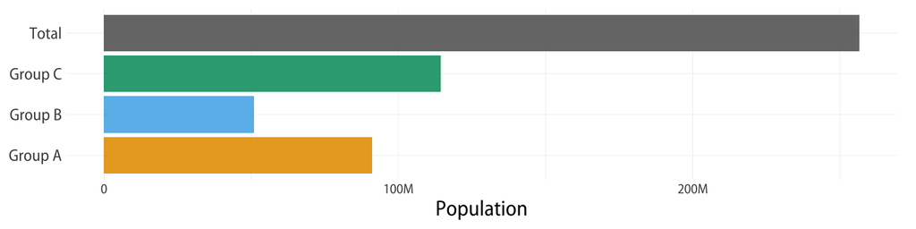

```r
df %>%
  pivot_longer(pop_a:pop_total) %>%
  group_by(name) %>%
  summarize(total = sum(value)) %>%
  ggplot(mapping = aes(x = total, y = name, fill = name)) +
  geom_col() +
  guides(fill = "none") +
  scale_fill_manual(values = alpha(c( my_oka[1:3], "gray40"), 0.9))  +
  scale_x_continuous(labels = scales::label_number_si()) +
  scale_y_discrete(labels = as_labeller(grp_names)) +
  labs(y = NULL, x = "Population")
```

Now we can plot the group-level population distributions across counties. We want to compare group distributions to one another and to the overall population distribution by county.

## Single-panel

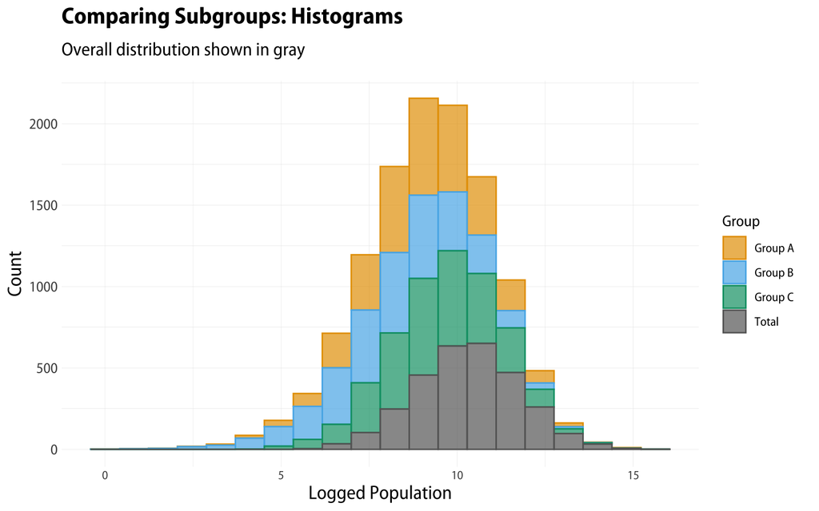

```r
df %>%
  pivot_longer(cols = pop_a:pop_total) %>%
  ggplot() +
  geom_histogram(mapping = aes(x = log(value), y = ..count..,
                          color = name, fill = name),
            stat = "bin", bins = 20, size = 0.5,
            alpha = 0.7) +
  scale_color_manual(values = alpha(c( my_oka[1:3], "gray40"), 1),
                     labels = as_labeller(grp_names)) +
  scale_fill_manual(values = alpha(c( my_oka[1:3], "gray40"), 0.6),
                    labels = as_labeller(grp_names)) +
  labs(x = "Logged Population", y = "Count", color = "Group",
       fill = "Group",
       title = "Comparing Subgroups: Histograms",
       subtitle = "Overall distribution shown in gray")
```

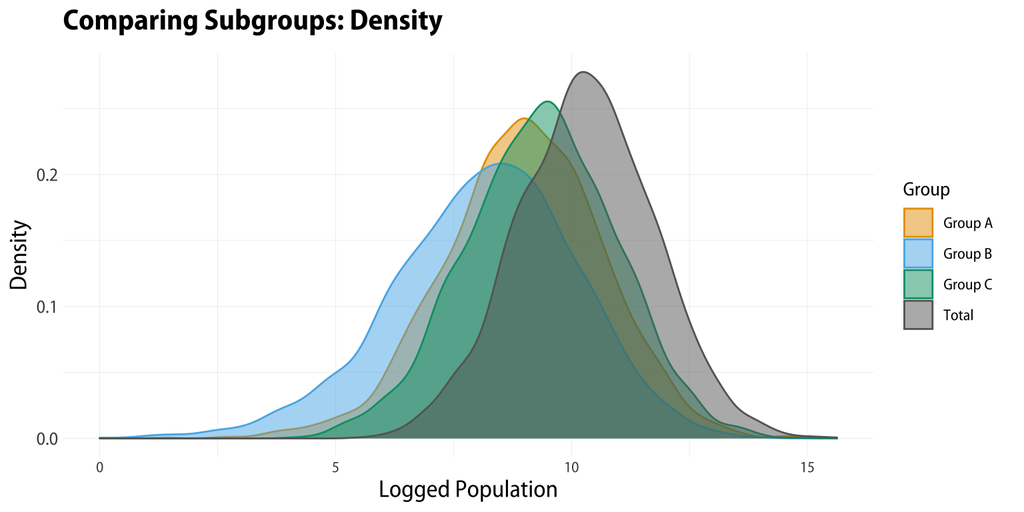

```r
df %>%
  pivot_longer(cols = pop_a:pop_total) %>%
  ggplot() +
  geom_density(mapping = aes(x = log(value),
                          color = name, fill = name),
            alpha = 0.5) +
  scale_color_manual(values = alpha(c( my_oka[1:3], "gray40"), 1),
                     labels = as_labeller(grp_names)) +
  scale_fill_manual(values = alpha(c( my_oka[1:3], "gray40"), 0.6),
                    labels = as_labeller(grp_names)) +
  labs(x = "Logged Population", y = "Density",
       title = "Comparing Subgroups: Density",
       color = "Group",
       fill = "Group")
```

## Ridgelines

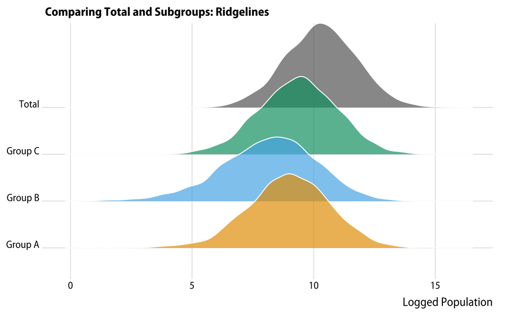

```r
df %>%
  pivot_longer(cols = pop_a:pop_total) %>%
  ggplot() +
  geom_density_ridges(mapping = aes(x = log(value + 1),
                                    y = name,
                                    fill = name),
                      color = "white") +
  scale_fill_manual(values = alpha(c( my_oka[1:3], "gray40"), 0.7)) +
  scale_y_discrete(labels = as_labeller(grp_names)) +
  guides(color = "none", fill = "none") +
  labs(x = "Logged Population", y = NULL, title = "Comparing Total and Subgroups: Ridgelines") +
  theme_ridges(font_family = "Myriad Pro SemiCondensed")
```

## Histograms

Now we’re going to facet our plots so that every subgroup gets its own panel. But we want to compare it to the overall distribution. So we pivot differently. The trick is to hold on to the total population by only pivoting the subgroups to long format. That leaves us with repeated values for the total population, `pop_total`, like this:

```r
df %>%
  pivot_longer(cols = pop_a:pop_c)
```

```
## # A tibble: 9,000 × 4
##     unit pop_total name   value
##    <int>     <dbl> <chr>  <dbl>
##  1     1      6467 pop_a   1008
##  2     1      6467 pop_b   1269
##  3     1      6467 pop_c   4194
##  4     2    211075 pop_a  60729
##  5     2    211075 pop_b  32579
##  6     2    211075 pop_c 117771
##  7     3    128243 pop_a  21186
##  8     3    128243 pop_b  50184
##  9     3    128243 pop_c  56876
## 10     4     76843 pop_a  22561
## # … with 8,990 more rows
```

When we draw the plot, we first call on `geom_histogram()` to draw the distribution of the total population, setting the color to gray. Then we call it again, separately, to draw the subgroups. Finally we facet on the subgroup names. This leaves us with a faceted plot where each panel shows one subpopulation’s distribution and, for reference behind it, the overall population distribution.

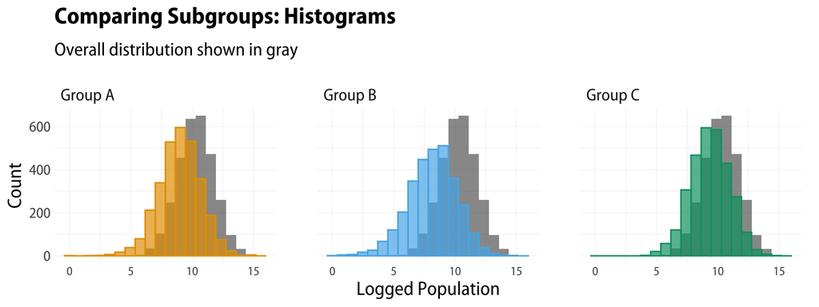

```r
df %>%
  pivot_longer(cols = pop_a:pop_c) %>%
  ggplot() +
  geom_histogram(mapping = aes(x = log(pop_total), y = ..count..),
                bins = 20, alpha = 0.7,
                fill = "gray40", size = 0.5) +
  geom_histogram(mapping = aes(x = log(value), y = ..count..,
                          color = name, fill = name),
            stat = "bin", bins = 20, size = 0.5,
            alpha = 0.7) +
  scale_fill_okabe_ito() +
  scale_color_okabe_ito() +
  guides(color = "none", fill = "none") +
  labs(x = "Logged Population", y = "Count",
       title = "Comparing Subgroups: Histograms",
       subtitle = "Overall distribution shown in gray") +
  facet_wrap(~ name, nrow = 1, labeller = as_labeller(grp_names))
```

This is a handy trick. We’ll use it repeatedly in the remaining figures, as we look at different ways of drawing the same comparison.

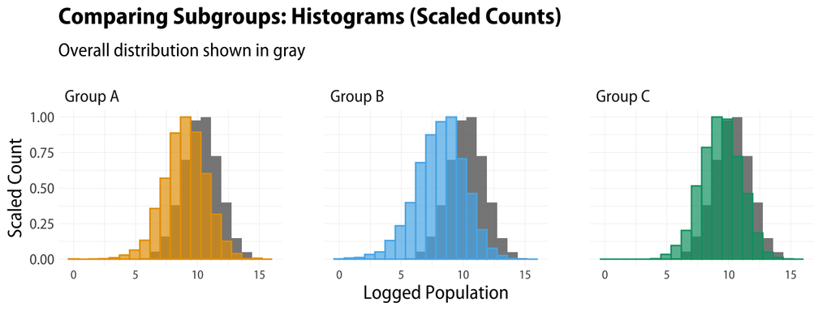

```r
df %>%
  pivot_longer(cols = pop_a:pop_c) %>%
  ggplot() +
  geom_histogram(mapping = aes(x = log(pop_total), y = ..ncount..),
                bins = 20, alpha = 0.8,
                fill = "gray40", size = 0.5) +
  geom_histogram(mapping = aes(x = log(value), y = ..ncount..,
                          color = name, fill = name),
            stat = "bin", bins = 20, size = 0.5,
            alpha = 0.7) +
  scale_fill_manual(values = alpha(my_oka, 0.7)) +
  scale_color_manual(values = alpha(my_oka, 1)) +
  guides(color = "none", fill = "none") +
  labs(x = "Logged Population", y = "Scaled Count",
       title = "Comparing Subgroups: Histograms (Scaled Counts)",
       subtitle = "Overall distribution shown in gray") +
  facet_wrap(~ name, nrow = 1, labeller = as_labeller(grp_names))
```

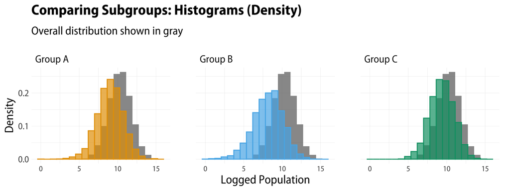

```r
df %>%
  pivot_longer(cols = pop_a:pop_c) %>%
  ggplot() +
  geom_histogram(mapping = aes(x = log(pop_total), y = ..density..),
                bins = 20, alpha = 0.7,
                fill = "gray40", size = 0.5) +
  geom_histogram(mapping = aes(x = log(value), y = ..density..,
                          color = name, fill = name),
            stat = "bin", bins = 20, size = 0.5,
            alpha = 0.7) +
  scale_fill_manual(values = alpha(my_oka, 0.7)) +
  scale_color_manual(values = alpha(my_oka, 1)) +
  guides(color = "none", fill = "none") +
  labs(x = "Logged Population", y = "Density",
       title = "Comparing Subgroups: Histograms (Density)",
       subtitle = "Overall distribution shown in gray") +
  facet_wrap(~ name, nrow = 1, labeller = as_labeller(grp_names))
```

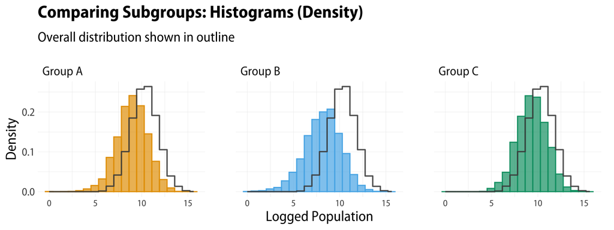

```r
df %>%
  pivot_longer(cols = pop_a:pop_c) %>%
  ggplot() +
  geom_histogram(mapping = aes(x = log(value), y = ..density..,
                          color = name, fill = name),
            stat = "bin", bins = 20, size = 0.5,
            alpha = 0.7) +
  geom_step(mapping = aes(x = log(pop_total), y = ..density..),
                bins = 20, alpha = 0.9,
                color = "gray30", size = 0.6,
            stat = "bin",
            direction = "mid") +
  scale_fill_manual(values = alpha(my_oka, 0.8)) +
  scale_color_manual(values = alpha(my_oka, 1)) +
  guides(color = "none", fill = "none") +
  labs(x = "Logged Population", y = "Density",
       title = "Comparing Subgroups: Histograms (Density)",
       subtitle = "Overall distribution shown in outline") +
  facet_wrap(~ name, nrow = 1, labeller = as_labeller(grp_names))
```

## Frequency Polygons

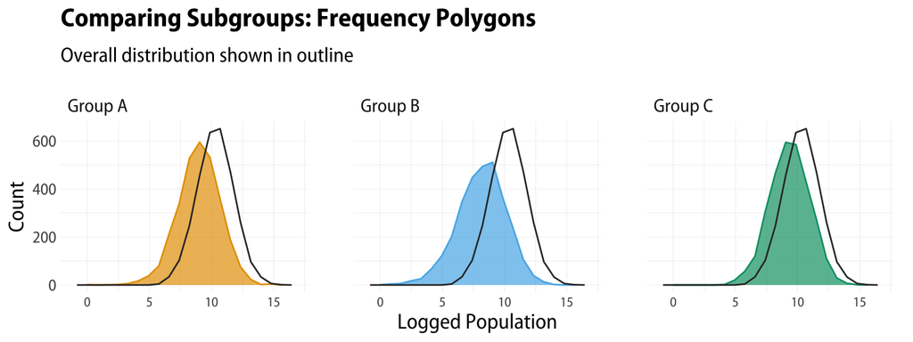

```r
df %>%
  pivot_longer(cols = pop_a:pop_c) %>%
  ggplot() +
  geom_area(mapping = aes(x = log(value), y = ..count..,
                          color = name, fill = name),
            stat = "bin", bins = 20, size = 0.5) +
  geom_freqpoly(mapping = aes(x = log(pop_total), y = ..count..),
                bins = 20,
                color = "gray20", size = 0.5) +
  scale_fill_manual(values = alpha(my_oka, 0.7)) +
  scale_color_manual(values = alpha(my_oka, 1)) +
  guides(color = "none", fill = "none") +
  labs(x = "Logged Population", y = "Count",
       title = "Comparing Subgroups: Frequency Polygons",
       subtitle = "Overall distribution shown in outline") +
  facet_wrap(~ name, nrow = 1, labeller = as_labeller(grp_names))
```

## Kernel Densities

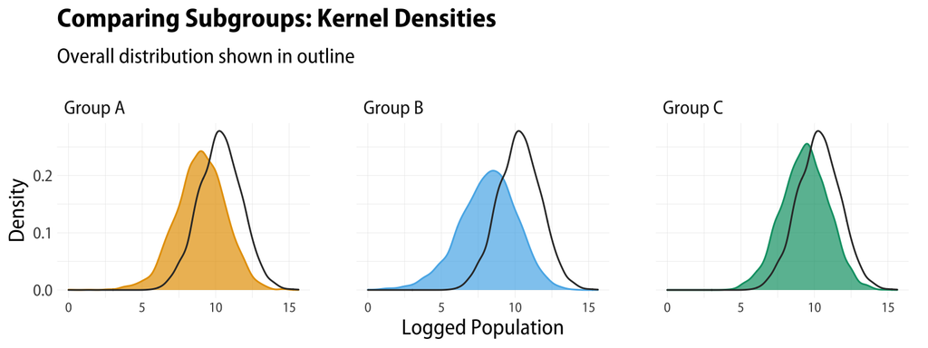

```r
df %>%
  pivot_longer(cols = pop_a:pop_c) %>%
  ggplot() +
  geom_density(mapping = aes(x = log(value),
                          color = name, fill = name),
            size = 0.5) +
  geom_density(mapping = aes(x = log(pop_total)),
                color = "gray20", size = 0.5) +
  scale_fill_manual(values = alpha(my_oka, 0.7)) +
  scale_color_manual(values = alpha(my_oka, 1)) +
  guides(color = "none", fill = "none") +
  labs(x = "Logged Population", y = "Density",
       title = "Comparing Subgroups: Kernel Densities",
       subtitle = "Overall distribution shown in outline") +
  facet_wrap(~ name, nrow = 1, labeller = as_labeller(grp_names))
```